# Markdown and Github Code

# First level

## *Text Emphasis*

### *Italics*

You can make a *phrase* *italicized* two ways: by wrapping it in a single set of *(astericks) or _ (underscores)

### **Bold text**

Similarly there are a couple of ways to make a **phrase** **bold**: by using two sets of ** (asterics) or __ (underscores)

## Numbered lists

1. List item 1
2. List item 2
3. List item 3

## Plain list

- List item 1
  - Subpoint 1
    - Subsubpoint 1
- List item 2
  - Subpoint 2
  - Subsupoint 2
- List item 3
  - Subpoint 3
    - Subsubpoint 3

## Don’t forget your spaces

-This is what happens -If you don’t include a space after the dash

## Paragraphs

Writing a paragraph is simple, you start anywhere and you just write the text which you want to read.

Once you are ready for a new paragraph all you have to do is leave a blank line between the last sentence of the previous paragraph and the first sentence of the new paragraph. Don’t expect there to be the normal indents on each paragraph thought!

## Paragraphs

Writing a paragraph is simple, you start anywhere and you just write the text which you want to read.

Once you are ready for a new paragraph all you have to do is leave a blank line between the last sentence of the previous paragraph and the first sentence of the new paragraph. Don’t expect there to be the normal indents on each paragraph thought!

See?

## Hyperlinks and Images

- [The website for class](http://politicaldatascience.com/)

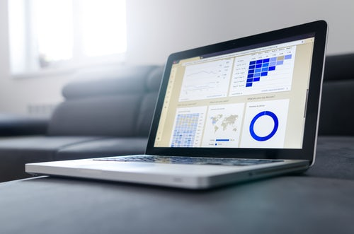

A computer with data